# Step 1: PTG Interim Summary — Promising Belief Targets

Nicole Cooper

2026-07-15

# Overview

**N = 299** (Cohorts 1–3 combined). This document summarizes findings from a Hornik & Woolf (1999) percentage-to-gain (PTG) analysis examining which beliefs are most associated with four behavioral intentions related to government funding of university research, and integrates belief network centrality (EBIC-GLASSO, 58 nodes, N/p = 5.2, 10 communities) to prioritize among similarly-ranked targets. It is intended as an interim working summary, not a final analysis.

# Methods note

**PTG** = (rate of “Definitely will” among those at the desired belief position) − (overall rate of “Definitely will”). Predictor dichotomized at the top response if positively correlated with intent composite, bottom if negatively correlated.

**Reliability threshold:** estimates based on fewer than 30 participants at the desired position are flagged (`[!]`). None of the targets in this summary trigger that flag.

**Ceiling flag:** beliefs where ≥ 60% already holds the desired position are excluded.

**Lower bound** = PTG − 1 SE (floored at 0). A lower bound ≥ 5 on at least two outcomes is the working criterion for a “credible” target (shaded rows in the table below).

**Centrality** = eigenvector centrality from the EBIC-GLASSO partial correlation network (58 nodes). Higher centrality = more connected to other influential beliefs. Percentile rank shown in parentheses.

**‡** From `govtfund_6` battery (dropped from network; α = 0.41). PTG valid but lower priority. **†** Not included as a node in the belief network.

# Cross-outcome summary table

Values are **PTG (lower bound)**. Centrality column shows eigenvector centrality (percentile rank). Shaded rows meet the credibility criterion (lb ≥ 5 on ≥ 2 outcomes).

| Belief | Dir | <sup>1</sup> | % to gain (lower bound) Talk to others | % to gain (lower bound) Share online | % to gain (lower bound) Oppose cuts | % to gain (lower bound) Support funding | Composite PTG<sup>2</sup> | Centrality (pctile)<sup>3</sup> |  |  |
| --- | --- | --- | --- | --- | --- | --- | --- | --- | --- | --- |
| Govt funding benefits |  |  |  |  |  |  |  |  |  |  |
| Results become publicly available | + |  | 13.3 (7.7) | 13.3 (8.0) | 8.9 (4.4) | 9.5 (4.8) |  |  | 11.2 | 0.30 (14%) |
| Funded researchers held to higher standards | + |  | 12.4 (5.8) | 12.5 (6.3) | 12.2 (6.4) | 7.7 (2.4) | 11.2 | 0.11 (0%) |  |  |
| Exciting research is sped up | + |  | 16.8 (10.7) | 11.7 (6.2) | 3.2 (0.0) | 5.6 (1.1) | 9.3 | 0.22 (7%) |  |  |
| Institutional trust |  |  |  |  |  |  |  |  |  |  |
| State public university system | + | † | 10.7 (4.9) | 10.2 (4.9) | 7.8 (3.1) | 10.2 (5.2) | 9.7 | — |  |  |
| Private colleges and universities | + |  | 12.6 (5.8) | 14.5 (7.9) | 3.3 (0.0) | 4.7 (0.0) | 8.8 | 0.49 (61%) |  |  |
| Local / economic impact |  |  |  |  |  |  |  |  |  |  |
| Local area would be negatively impacted by cuts | − |  | 12.9 (7.6) | 9.9 (5.2) | 10.1 (5.7) | 8.3 (4.0) | 10.3 | 0.43 (39%) |  |  |
| boosts the economy | + |  | 11.5 (6.6) | 8.4 (4.0) | 4.9 (1.3) | 9.3 (5.2) | 8.5 | 0.60 (84%) |  |  |
| Personal relevance |  |  |  |  |  |  |  |  |  |  |
| People you care about | + |  | 22.8 (16.5) | 19.3 (13.4) | 7.8 (3.1) | 11.7 (6.6) | 15.4 | 0.56 (77%) |  |  |
| Disadvantaged individuals | + |  | 14.0 (7.9) | 14.8 (9.0) | 7.2 (2.5) | 6.5 (1.8) | 10.6 | 0.28 (11%) |  |  |
| Local community | + |  | 16.6 (10.2) | 12.3 (6.5) | 6.0 (1.4) | 7.0 (2.1) | 10.5 | 0.48 (60%) |  |  |
| You personally | + |  | 14.4 (8.5) | 8.1 (3.0) | 8.8 (4.1) | 9.6 (4.7) | 10.2 | 0.53 (70%) |  |  |
| Researcher integrity |  |  |  |  |  |  |  |  |  |  |
| Researchers lie to maintain funding | − |  | 17.6 (10.6) | 17.5 (10.8) | 6.9 (1.7) | 6.3 (1.1) | 12.1 | 0.48 (51%) |  |  |
| University researchers motivated primarily by profit | − | ‡ | 21.0 (14.5) | 16.8 (10.8) | 4.1 (0.0) | 5.1 (0.5) | 11.8 | — |  |  |
| Money spent on less important things | − |  | 17.5 (10.1) | 12.2 (5.5) | 8.9 (3.1) | 8.3 (2.5) | 11.7 | 0.44 (44%) |  |  |
| Taxpayer money is wasted | − |  | 11.3 (5.1) | 15.3 (9.2) | 4.9 (0.3) | 4.3 (0.0) | 9.0 | 0.56 (75%) |  |  |
| Science salience |  |  |  |  |  |  |  |  |  |  |
| I think about the impact of science on my daily life | + |  | 19.4 (12.8) | 11.4 (5.6) | 16.8 (11.0) | 19.6 (13.5) | 16.8 | 0.35 (25%) |  |  |
| Clear how to apply research findings in my life | + |  | 12.9 (6.2) | 11.0 (4.9) | 10.6 (5.0) | 16.0 (9.8) | 12.6 | 0.43 (35%) |  |  |
| University contributions |  |  |  |  |  |  |  |  |  |  |
| Increased compassion and tolerance | + |  | 16.6 (11.0) | 14.3 (9.1) | 7.8 (3.5) | 7.2 (2.9) | 11.5 | 0.46 (47%) |  |  |
| Better international relations | + |  | 20.1 (14.2) | 14.6 (9.2) | 2.1 (0.0) | 4.1 (0.0) | 10.2 | 0.43 (37%) |  |  |

<sup>1</sup> ‡ govtfund_6 battery dropped from network (α = 0.41). † Not a network node.  
<sup>2</sup> Composite = mean PTG across all four outcomes.  
<sup>3</sup> Eigenvector centrality from the EBIC-GLASSO network. Percentile rank in parentheses.

# Outcome-by-outcome highlights

## Talk to others about cuts

| Block | Belief | Dir | PTG (lb) | ROR | n |
| --- | --- | --- | --- | --- | --- |
| Research Beliefs | People you care about | positive | 22.8 (16.5) | 6.49 | 66 |
| Govt Funding | University researchers motivated primarily by profit | negative | 21.0 (14.5) | 5.27 | 61 |
| University Perceptions | Better international relations | positive | 20.1 (14.2) | 5.87 | 74 |
| Research Beliefs | I think about the impact of science on my daily life | positive | 19.4 (12.8) | 4.55 | 58 |
| Govt Funding | Researchers lie to maintain funding | negative | 17.6 (10.6) | 3.69 | 49 |

The personal relevance cluster dominates. **People you care about** (PTG = 22.8, ROR = 6.49) is the single strongest target: proximate personal concern mobilizes interpersonal communication. Multiple research_3 items appear (local community, you personally, disadvantaged individuals), reinforcing a stakes/proximity framing.

## Share info online about cuts

| Block | Belief | Dir | PTG (lb) | ROR | n |
| --- | --- | --- | --- | --- | --- |
| Research Beliefs | People you care about | positive | 19.3 (13.4) | 7.36 | 66 |
| Govt Funding | Researchers lie to maintain funding | negative | 17.5 (10.8) | 4.86 | 49 |
| Govt Funding | University researchers motivated primarily by profit | negative | 16.8 (10.8) | 5.36 | 61 |
| Govt Funding | Taxpayer money is wasted | negative | 15.3 (9.2) | 4.44 | 57 |
| Research Beliefs | Disadvantaged individuals | positive | 14.8 (9.0) | 4.50 | 62 |

## Contact reps to oppose cuts

| Block | Belief | Dir | PTG (lb) | ROR | n |
| --- | --- | --- | --- | --- | --- |
| Research Beliefs | I think about the impact of science on my daily life | positive | 16.8 (11.0) | 9.27 | 58 |
| Govt Funding | Funded researchers held to higher standards | positive | 12.2 (6.4) | 4.80 | 51 |
| Research Beliefs | Clear how to apply research findings in my life | positive | 10.6 (5.0) | 3.98 | 50 |
| Govt Funding | Local area would be negatively impacted by cuts | negative | 10.1 (5.7) | 6.22 | 86 |

PTG values are lower overall — contacting representatives is a higher-effort behavior. **Science salience** (thinking about the impact of science on daily life) becomes the top target (PTG = 16.8, ROR = 9.27). **Local impact** also has a reliable estimate (lower bound = 5.7): connecting research cuts to local constituents may be particularly effective for motivating representative contact.

## Contact reps to support funding

| Block | Belief | Dir | PTG (lb) | ROR | n |
| --- | --- | --- | --- | --- | --- |
| Research Beliefs | I think about the impact of science on my daily life | positive | 19.6 (13.5) | 11.10 | 58 |
| Research Beliefs | Clear how to apply research findings in my life | positive | 16.0 (9.8) | 6.24 | 50 |
| Govt Funding | The general public | positive | 13.8 (6.3) | 4.12 | 32 |
| Research Beliefs | People you care about | positive | 11.7 (6.6) | 4.95 | 66 |
| Higher Education | State public university system | positive | 10.2 (5.2) | 4.09 | 66 |

**Science salience** is the strongest target here as well (PTG = 19.6, ROR = 11.1). **Clear how to apply research findings** ranks 2nd (PTG = 16) — applied relevance framing may be particularly effective for motivating proactive support.

# Network centrality

Eigenvector centrality indicates how well-connected each belief is to other influential beliefs in the network. A high-centrality belief is embedded in the broader structure and may cascade: shifting it could move adjacent beliefs as well. A low-centrality belief predicts behavior but is structurally isolated — it may respond well to direct messaging but is unlikely to produce downstream ripple effects.

The priority zone is the **upper-right quadrant** below: above-average on both composite PTG and centrality.

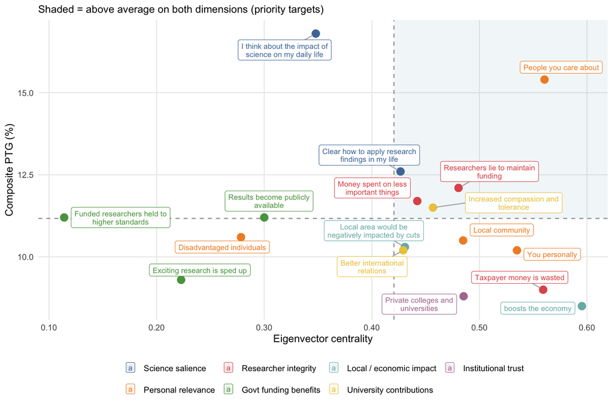

| Theme | Belief | Composite PTG | Centrality | Community |
| --- | --- | --- | --- | --- |
| Local / economic impact | boosts the economy | 8.5 | 0.60 (84%) | 8 |
| Personal relevance | People you care about | 15.4 | 0.56 (77%) | 2 |
| Researcher integrity | Taxpayer money is wasted | 9 | 0.56 (75%) | 1 |
| Personal relevance | You personally | 10.2 | 0.53 (70%) | 2 |
| Institutional trust | Private colleges and universities | 8.8 | 0.49 (61%) | 5 |
| Personal relevance | Local community | 10.5 | 0.48 (60%) | 2 |
| Researcher integrity | Researchers lie to maintain funding | 12.1 | 0.48 (51%) | 1 |
| University contributions | Increased compassion and tolerance | 11.5 | 0.46 (47%) | 2 |
| Researcher integrity | Money spent on less important things | 11.7 | 0.44 (44%) | 1 |
| Local / economic impact | Local area would be negatively impacted by cuts | 10.3 | 0.43 (39%) | 4 |

[output cut: 7 more lines]

## Quadrant interpretation

| Quadrant | Belief | Theme | Composite PTG | Centrality |
| --- | --- | --- | --- | --- |
| High PTG + High centrality (priority) | People you care about | Personal relevance | 15.4 | 0.56 (77%) |
| High PTG + High centrality (priority) | Clear how to apply research findings in my life | Science salience | 12.6 | 0.43 (35%) |
| High PTG + High centrality (priority) | Researchers lie to maintain funding | Researcher integrity | 12.1 | 0.48 (51%) |
| High PTG + High centrality (priority) | Money spent on less important things | Researcher integrity | 11.7 | 0.44 (44%) |
| High PTG + High centrality (priority) | Increased compassion and tolerance | University contributions | 11.5 | 0.46 (47%) |
| High PTG + Low centrality (direct target) | I think about the impact of science on my daily life | Science salience | 16.8 | 0.35 (25%) |
| High PTG + Low centrality (direct target) | Results become publicly available | Govt funding benefits | 11.2 | 0.30 (14%) |
| High PTG + Low centrality (direct target) | Funded researchers held to higher standards | Govt funding benefits | 11.2 | 0.11 (0%) |

**High PTG + High centrality** beliefs are the primary targets: shifting them is both associated with behavior change and likely to propagate through the belief network.

**High PTG + Low centrality** beliefs are strong direct targets but structurally isolated: they predict behavior without being well-connected to other beliefs. Useful for direct messaging, but less likely to produce broader attitude ripple effects.

# Key takeaways

# Caveats

- **Correlational estimates only.** PTG identifies co-variation with intent; experimental manipulation is required to confirm causal effects.
- **N = 299 limits per-outcome power.** Lower bounds below ~5% should be treated as noise.
- **Network N/p = 5.2** (58 nodes). At the lower edge of acceptable range; centrality estimates should be treated as directional, not precise.
- **govtfund_6 items (‡)** excluded from network due to poor coherence. PTG estimates included here but lower priority.
- **research_4_6** (“Science makes our way of life change too fast”) appears in unexpected direction for political outcomes; dropped from network due to reverse-coding instability. Do not treat as an intervention target.

*Generated 2026-07-15. PTG source: 04_promising_beliefs.csv. Network source: 05_belief_network.csv (N = 299, 58 nodes, N/p = 5.2).*